# FRA_NitinYadav

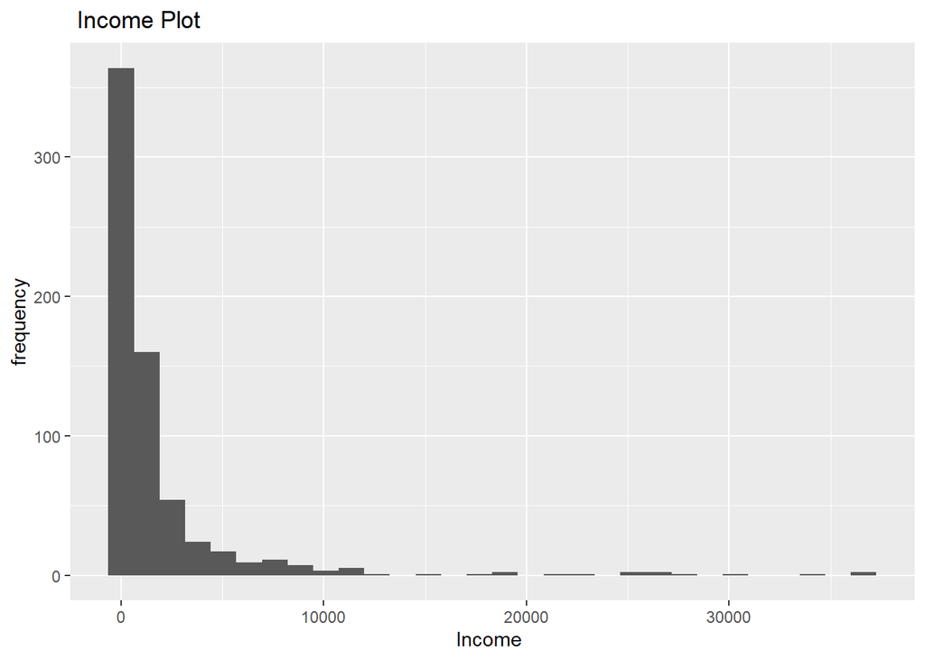

```r
qplot(Test_Data$Total.income, data = Test_Data, main=" Income Plot ", xlab = "Income ", ylab = "frequency")
```

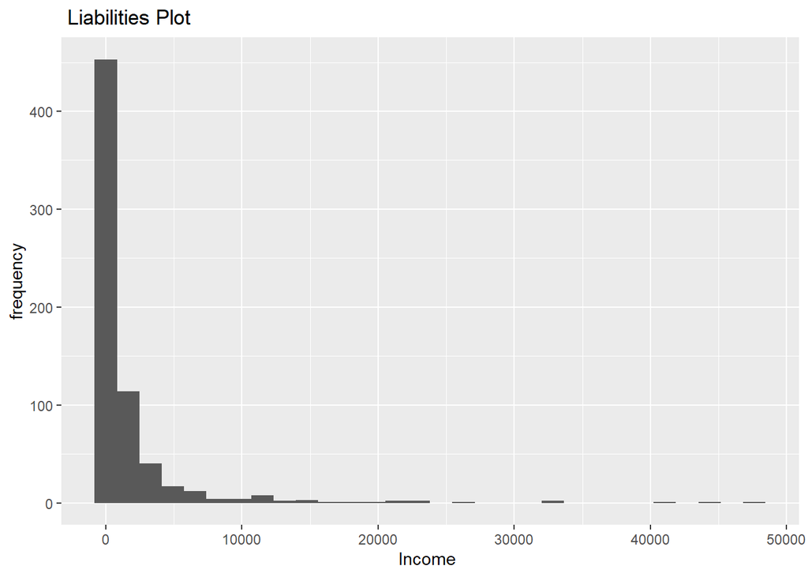

```r
qplot(Test_Data$Total.liabilities, data = Test_Data, main=" Liabilities Plot ", xlab = "Income ", ylab = "frequency")
```

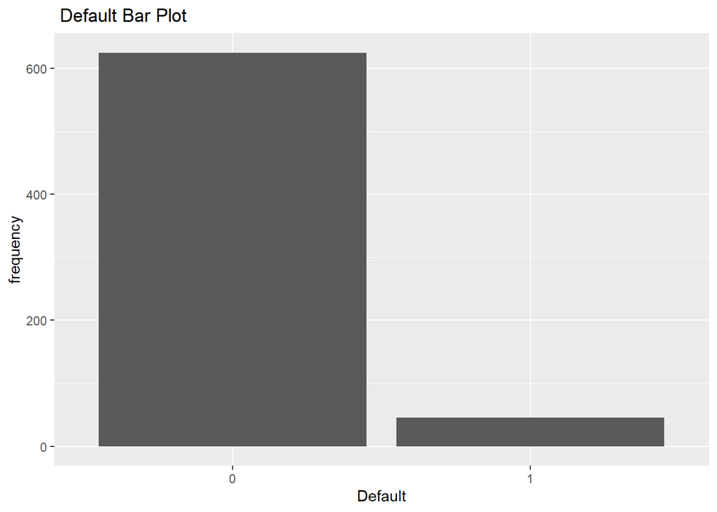

```r
# Categorical

qplot(Test_Data$Default, data = Test_Data, main=" Default Bar Plot", xlab = "Default", ylab = "frequency")
```

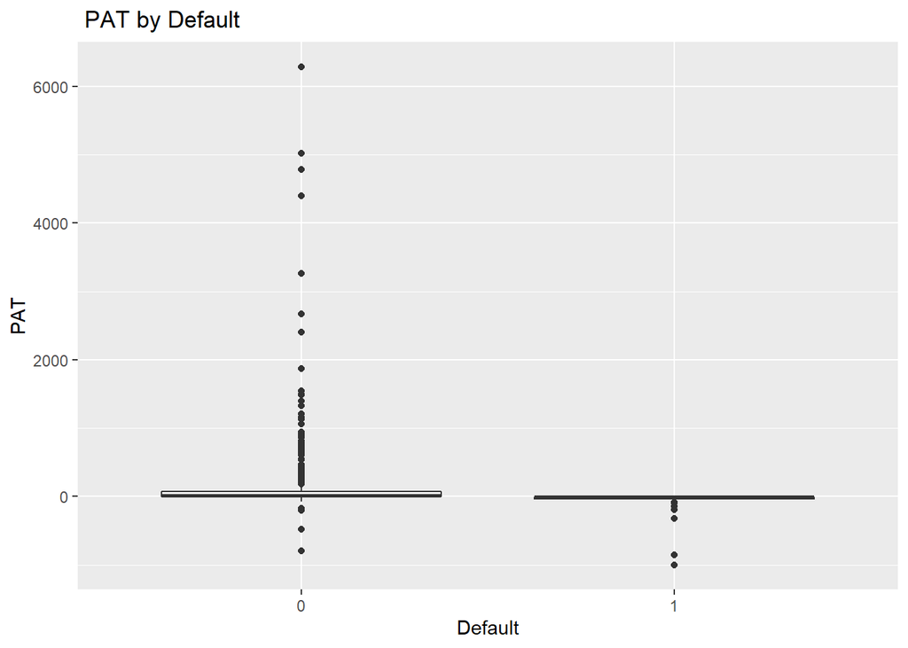

```r
# Categorical and numerical together

qplot(Test_Data$Default,Test_Data$Profit.after.tax, data = Test_Data, , geom="boxplot",main=" PAT by Default", xlab = "Default", ylab ="PAT")
```

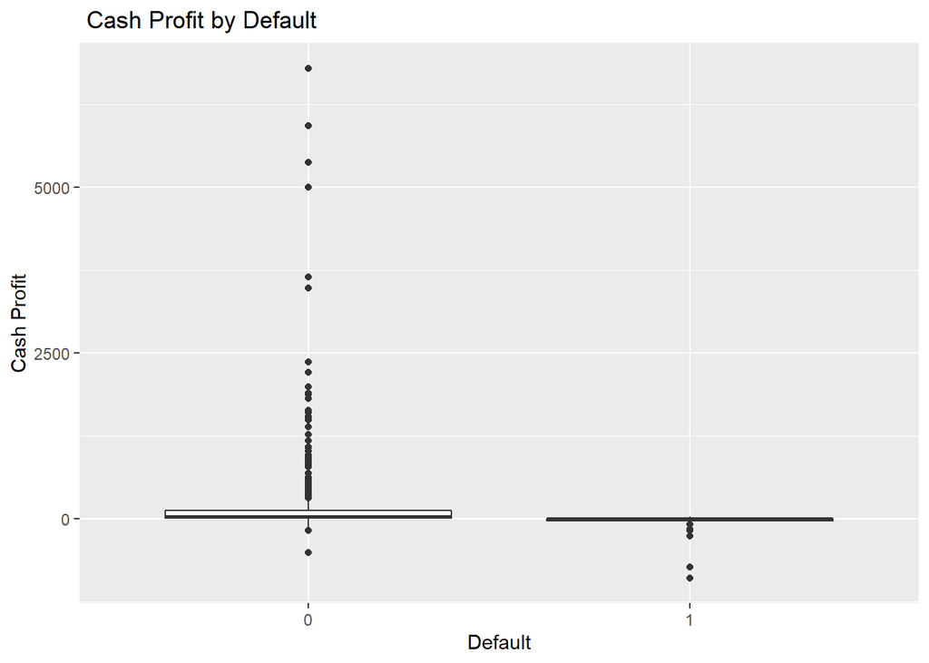

```r
qplot(Test_Data$Default,Test_Data$Cash.profit, data = Test_Data, , geom="boxplot",main=" Cash Profit by Default", xlab = "Default", ylab ="Cash Profit")
```

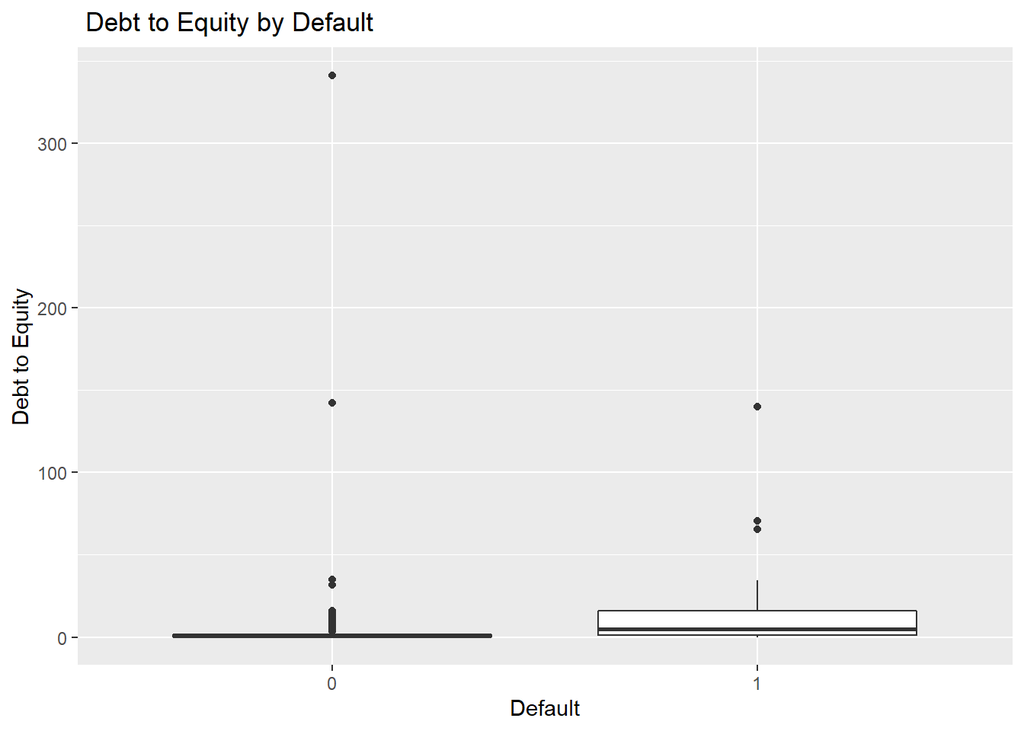

```r
qplot(Test_Data$Default,Test_Data$Debt.to.equity.ratio..times., data = Test_Data, , geom="boxplot",main=" Debt to Equity by Default", xlab = "Default", ylab ="Debt to Equity")
```

[figure not shown]

```r
qplot(Test_Data$Default,Test_Data$ReturnonAsset, data = Test_Data, , geom="boxplot",main=" Return on Equity by Default", xlab = "Default", ylab ="Return on Equity")
```

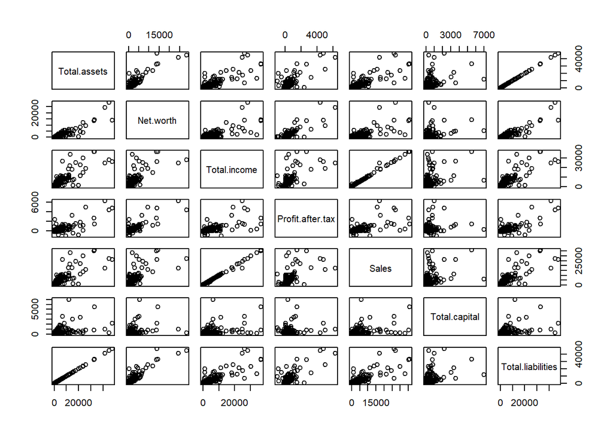

```r
# Numerical against numerical and color the dots by categorical variable

plot(Test_Data[,c(1:4,6,7,15)])
```

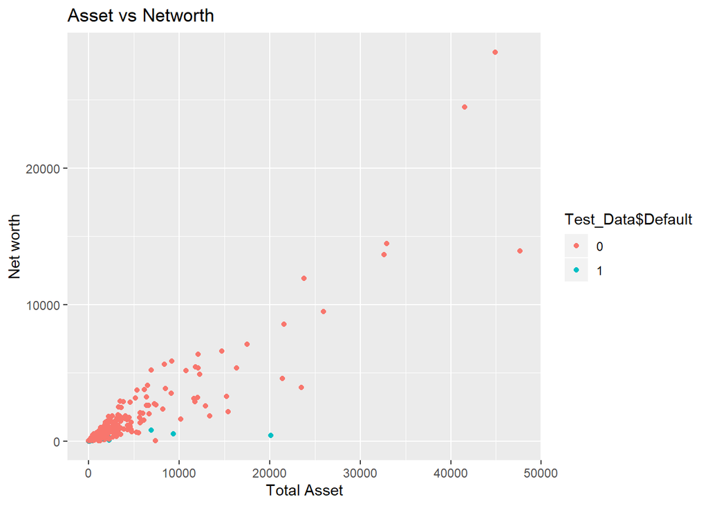

```r
qplot(Test_Data$Total.assets, Test_Data$Net.worth, data = Test_Data, color=Test_Data$Default , main = "Asset vs Networth", xlab = "Total Asset", ylab = "Net worth")
```

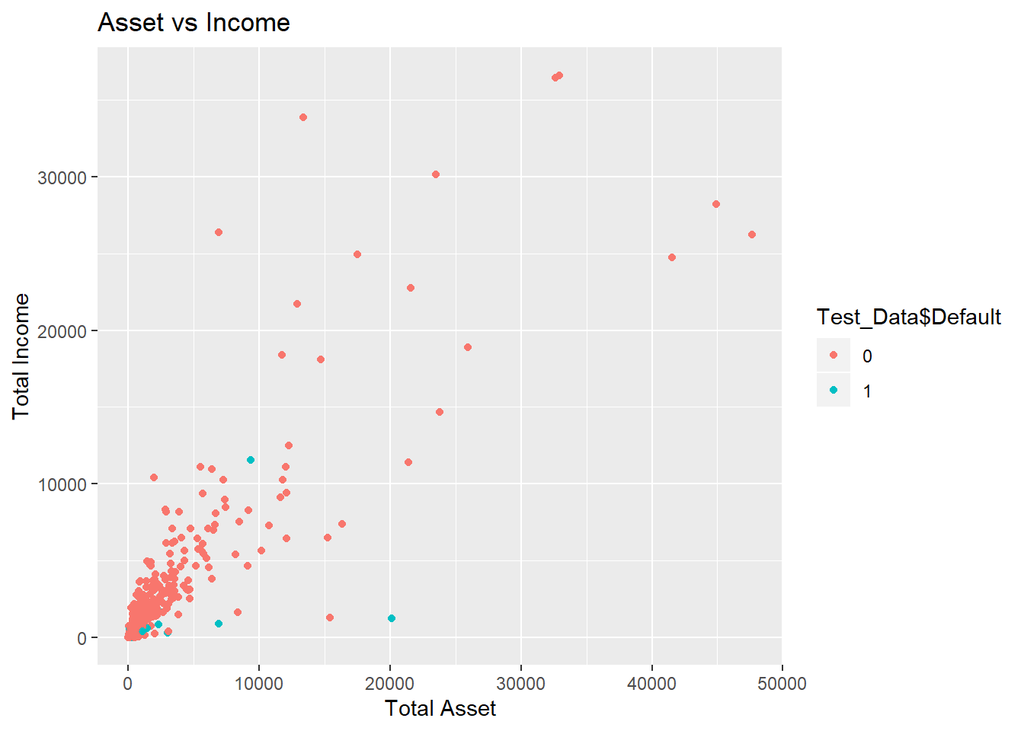

```r
qplot(Test_Data$Total.assets, Test_Data$Total.income, data = Test_Data, color=Test_Data$Default , main = "Asset vs Income", xlab = "Total Asset", ylab = "Total Income")
```

[figure not shown]

```r
qplot(Test_Data$Sales, Test_Data$Profit.after.tax, data = Test_Data, color=Test_Data$Default , main = "Asset vs Income", xlab = "Sales", ylab = "Profit After Tax")
```

[figure not shown]

```r
qplot(Test_Data$Total.liabilities, Test_Data$Profit.after.tax, data = Test_Data, color=Test_Data$Default , main = "Liabilities vs PAT", xlab = "PAT", ylab = "Total Liabilities")
```

```r
by(Test_Data, INDICES = Test_Data$Default, FUN = summary)
```

```
## Test_Data$Default: 0
##   Total.assets       Net.worth        Total.income     Profit.after.tax
##  Min.   :    0.7   Min.   :    0.3   Min.   :    0.0   Min.   :-799.9
##  1st Qu.:  115.8   1st Qu.:   45.8   1st Qu.:  130.6   1st Qu.:   1.5
##  Median :  425.8   Median :  136.1   Median :  569.4   Median :  12.9
##  Mean   : 1800.9   Mean   :  696.3   Mean   : 1945.8   Mean   : 137.7
##  3rd Qu.: 1323.9   3rd Qu.:  482.7   3rd Qu.: 1727.4   3rd Qu.:  71.8
##  Max.   :47628.8   Max.   :28495.1   Max.   :36623.3   Max.   :6289.3
##   Cash.profit         Sales         Total.capital      Borrowings
##  Min.   :-509.7   Min.   :    0.1   Min.   :   0.5   Min.   :    0.2
##  1st Qu.:   4.9   1st Qu.:  127.4   1st Qu.:  15.0   1st Qu.:   24.9
##  Median :  27.3   Median :  555.7   Median :  48.7   Median :  105.2
##  Mean   : 183.6   Mean   : 1882.7   Mean   : 169.0   Mean   :  572.6
##  3rd Qu.: 125.6   3rd Qu.: 1697.4   3rd Qu.: 120.0   3rd Qu.:  358.8
##  Max.   :6801.2   Max.   :35926.7   Max.   :7003.8   Max.   :20587.5
##  Current.liabilities...provisions Net.working.capital Quick.ratio..times.
##  Min.   :    0.1                  Min.   :-12564.0    Min.   :  0.000
##  1st Qu.:   18.8                  1st Qu.:     0.2    1st Qu.:  0.460
##  Median :   81.4                  Median :    27.6    Median :  0.690
##  Mean   :  452.6                  Mean   :   128.6    Mean   :  2.082
##  3rd Qu.:  296.0                  3rd Qu.:   105.5    3rd Qu.:  1.080
##  Max.   :16288.1                  Max.   : 16213.6    Max.   :341.000
##  Current.ratio..times. Debt.to.equity.ratio..times.
##  Min.   :  0.000       Min.   :  0.000
##  1st Qu.:  0.980       1st Qu.:  0.220
##  Median :  1.260       Median :  0.760
##  Mean   :  3.055       Mean   :  2.142
##  3rd Qu.:  1.760       3rd Qu.:  1.540
##  Max.   :505.000       Max.   :341.180
##  Cash.to.current.liabilities..times. Total.liabilities ReturnonAsset
##  Min.   :  0.0000                    Min.   :    0.7   Min.   : 0.0000
##  1st Qu.:  0.0300                    1st Qu.:  115.8   1st Qu.: 0.7414
##  Median :  0.0800                    Median :  425.8   Median : 1.1829
##  Mean   :  0.7834                    Mean   : 1800.9   Mean   : 1.3905
##  3rd Qu.:  0.2000                    3rd Qu.: 1323.9   3rd Qu.: 1.7432
##  Max.   :165.0000                    Max.   :47628.8   Max.   :11.8443
##  ReturnonEquity     DebttoCapital      Incometosales
##  Min.   :-2.55233   Min.   :  0.0090   Min.   :  0.000
##  1st Qu.: 0.03197   1st Qu.:  0.8929   1st Qu.:  1.002
##  Median : 0.11195   Median :  2.5771   Median :  1.007
```

[output cut: 46 more lines]

```
##  Max.   :2.7800                      Max.   :20099.1   Max.   :4.790657
##  ReturnonEquity     DebttoCapital       Incometosales
##  Min.   :-11.0000   Min.   :  0.00745   Min.   :0.00062
##  1st Qu.: -1.5864   1st Qu.:  0.80000   1st Qu.:1.00000
##  Median : -0.9070   Median :  2.09386   Median :1.01472
##  Mean   : -1.3538   Mean   :  7.17891   Mean   :1.08734
##  3rd Qu.: -0.1504   3rd Qu.:  5.49729   3rd Qu.:1.05014
##  Max.   :  3.1429   Max.   :104.75000   Max.   :5.00000
##  ProfittoSales       ProfittoIncome      Default - 1
##  Min.   :-25.00000   Min.   :-26.00000   0: 0
##  1st Qu.: -0.30121   1st Qu.: -0.38240   1:45
##  Median : -0.08895   Median : -0.12389
##  Mean   : -0.79873   Mean   : -1.53250
##  3rd Qu.: -0.01983   3rd Qu.: -0.02695
##  Max.   :  0.70968   Max.   :  0.70968
```

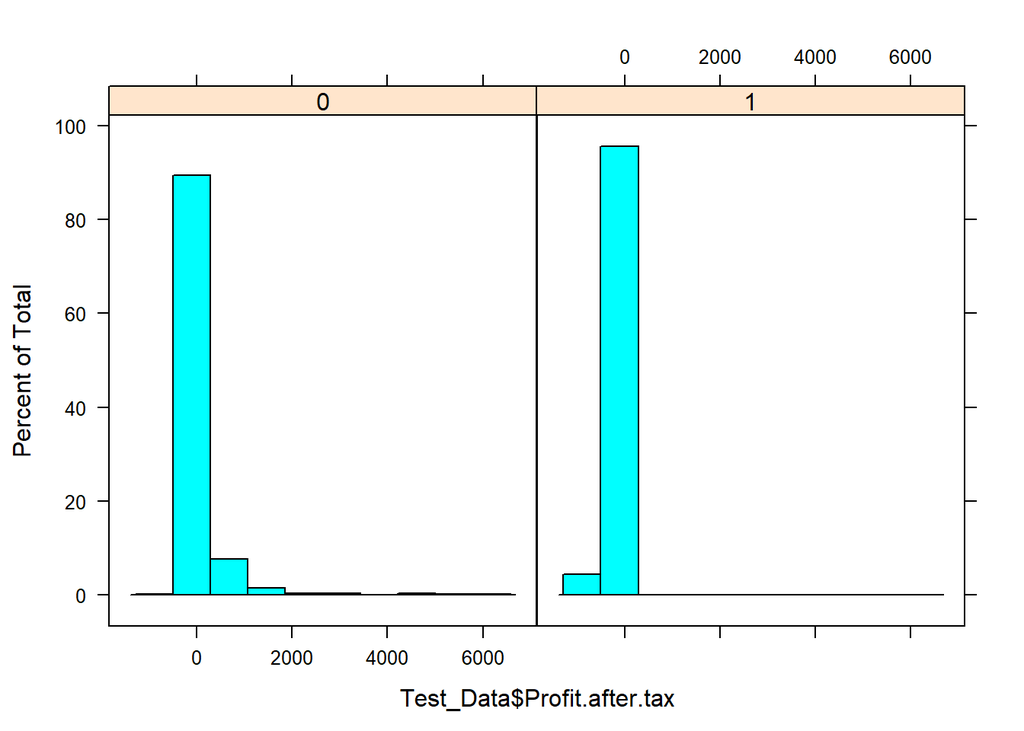

```r
histogram(~Test_Data$Profit.after.tax|factor(Test_Data$Default), data = Train_Data)
```

```r
## Doing the prediction using the Test Data
colnames(Test_Data)
```

```
##  [1] "Total.assets"
##  [2] "Net.worth"
##  [3] "Total.income"
##  [4] "Profit.after.tax"
##  [5] "Cash.profit"
##  [6] "Sales"
##  [7] "Total.capital"
##  [8] "Borrowings"
##  [9] "Current.liabilities...provisions"
## [10] "Net.working.capital"
## [11] "Quick.ratio..times."
## [12] "Current.ratio..times."
## [13] "Debt.to.equity.ratio..times."
## [14] "Cash.to.current.liabilities..times."
## [15] "Total.liabilities"
## [16] "ReturnonAsset"
## [17] "ReturnonEquity"
## [18] "DebttoCapital"
## [19] "Incometosales"
## [20] "ProfittoSales"
## [21] "ProfittoIncome"
## [22] "Default - 1"
```

```r
str(Test_Data$Incometosales)
```

```
##  num [1:670] 1.01 1 1.02 1 1.01 ...
```

```r
colnames(Test_Data)[which(names(Test_Data) == "Default - 1")] = "Default"


dim(Test_Data)
```

```
## [1] 670  22
```

```r
str(Test_Data)
```

```
## 'data.frame':    670 obs. of  22 variables:
##  $ Total.assets                       : num  971 675 532 858 823 ...
##  $ Net.worth                          : num  276 212 120 201 349 ...
##  $ Total.income                       : num  2185 819 564 3576 1034 ...
##  $ Profit.after.tax                   : num  100.2 19.7 -42.4 -37.5 21.4 ...
##  $ Cash.profit                        : num  182.3 50.5 -35.3 37.3 62.7 ...
##  $ Sales                              : num  2171 817 552 3573 1027 ...
##  $ Total.capital                      : num  48 114 47.1 50.5 33 ...
##  $ Borrowings                         : num  177.3 339.8 17.5 524.2 162.3 ...
##  $ Current.liabilities...provisions   : num  328.5 100.5 240.1 75.2 299.6 ...
##  $ Net.working.capital                : num  134.2 123.6 -97.1 99.6 75.3 ...
##  $ Quick.ratio..times.                : num  0.92 0.48 0.32 0.51 0.58 0.97 166 0.52 0.88 0.6 ...
##  $ Current.ratio..times.              : num  1.31 1.39 0.6 1.23 1.19 1.86 166 1.56 1.19 0.55 ...
##  $ Debt.to.equity.ratio..times.       : num  0.64 1.61 0.15 2.6 0.46 0.32 0.05 1.24 0 1.81 ...
##  $ Cash.to.current.liabilities..times.: num  0.09 0.03 0.04 0.08 0.08 0 165 0.03 0.35 0.23 ...
##  $ Total.liabilities                  : num  971 675 532 858 823 ...
##  $ ReturnonAsset                      : num  2.25 1.21 1.06 4.17 1.26 ...
##  $ ReturnonEquity                     : num  0.3633 0.0931 -0.3527 -0.1862 0.0613 ...
##  $ DebttoCapital                      : num  3.694 2.981 0.372 10.38 4.918 ...
##  $ Incometosales                      : num  1.01 1 1.02 1 1.01 ...
##  $ ProfittoSales                      : num  0.0462 0.0241 -0.0768 -0.0105 0.0208 ...
##  $ ProfittoIncome                     : num  0.0459 0.024 -0.0752 -0.0105 0.0207 ...
##  $ Default                            : Factor w/ 2 levels "0","1": 1 1 2 1 1 1 1 1 1 1 ...
```

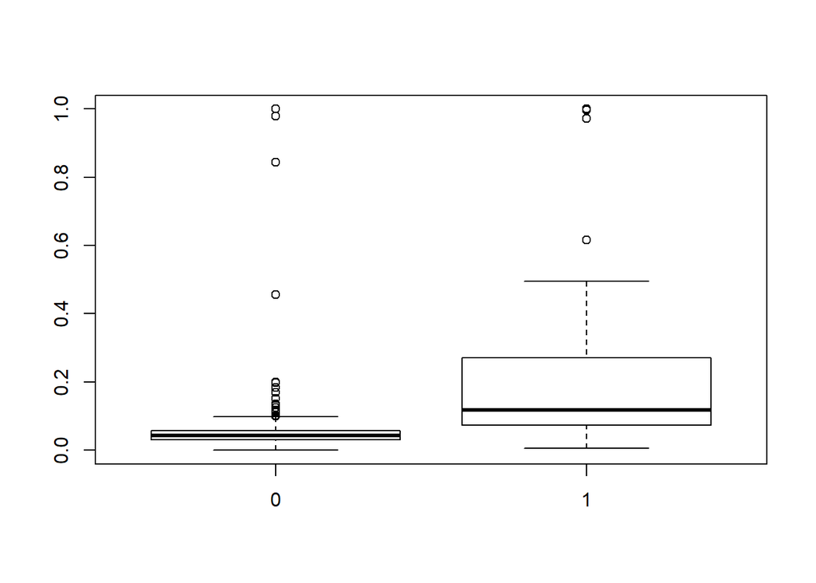

```r
Pred.Test=predict(Tr_L7,newdata = Test_Data,type = "response")
plot(Test_Data$Default,Pred.Test)
```

## Model performance for Test Set

We take threshold of 8% to find that below this threshold there is minimum prob. of default and above this threshold the risk of default increases.

OVerall Accuracy - 91% ie in identifying the 1s and 0s correctly which means 10% is missclassification

Sensitivity - 71% ie ability of model to predicting 1s correctly. We can increase this value by reducing the threshold but that will also increase the Loss rate and missclasification.

Specificity - 92% , the ability to identify 0s correctly

ROC - 86%

KS Calculation -(Difference between %Cumulative Right and % Cumulative Wrong) KS values intrepret that the model is moderatley good in terms of separating the “1”s and “0”s and we can interpret that the model holds a good prediction ability.

KS Score - 65%

AUC - 86%

Gini - 46%

Concordance - 86%

```r
## Model Performance for Train Set

Test.logit=confusion.matrix(Test_Data$Default,Pred.Test,threshold = 0.08)
Test.logit
```

```
##     obs
## pred   0  1
##    0 578 13
##    1  47 32
## attr(,"class")
## [1] "confusion.matrix"
```

```r
## Accuracy of model

accuracy.T<-sum(diag(Test.logit))/sum(Test.logit)
accuracy.T
```

```
## [1] 0.9104478
```

```r
## Sensitivity

sensitivity.T<-Test.logit[2,2]/(Test.logit[1,2]+Test.logit[2,2])
sensitivity.T
```

```
## [1] 0.7111111
```

```r
## Specificity

specificity.T<-Test.logit[1,1]/(Test.logit[1,1]+Test.logit[2,1])
specificity.T
```

```
## [1] 0.9248
```

```r
## Loss Function - When we predicted company will not default but actually company defaulted
loss.T<-Test.logit[1,2]/(Test.logit[1,2]+Test.logit[1,1])
loss.T
```

```
## [1] 0.02199662
```

```r
## OTher Model performance for Test Data set

## Roc curve for the model

ROCRTest = prediction(Pred.Test,Test_Data$Default)
as.numeric(performance(ROCRTest, "auc")@y.values)
```

```
## [1] 0.8575289
```

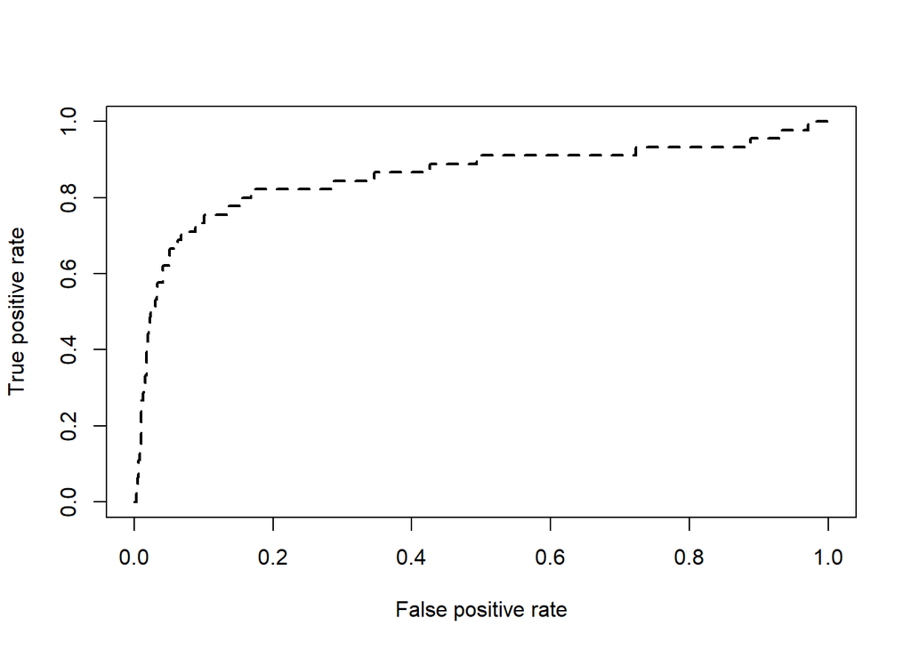

```r
perf1 = performance(ROCRTest, "tpr","fpr")
plot(perf1,col="black",lty=2, lwd=2)
```

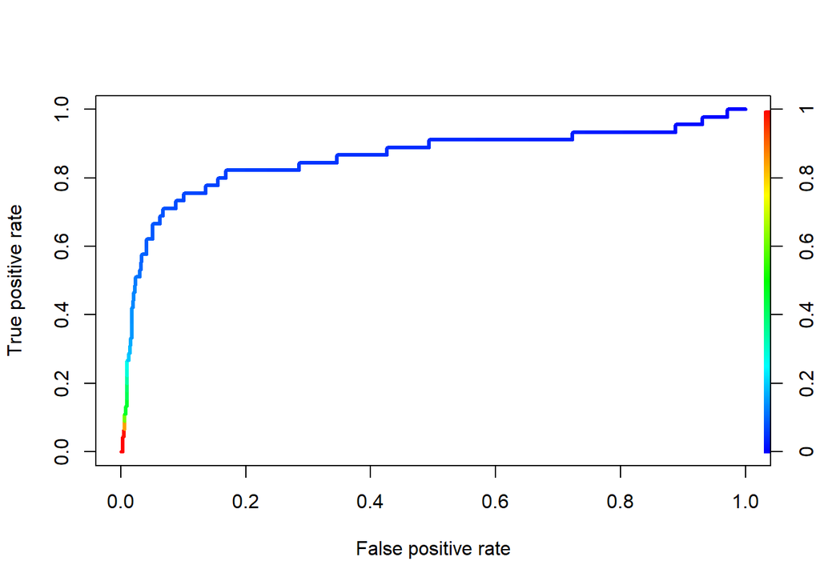

```r
plot(perf1,lwd=3,colorize = TRUE)
```

```r
## KS Calculation -(Difference between %Cumulative Right and % Cumulative Wrong)
## KS values intrepret that the model is moderatley good in terms of separating the "1"s and "0"s and we can interpret that the model holds a good prediction ability.

KS_Test=max(perf1@y.values[[1]]-perf1@x.values[[1]])
print(KS_Test)
```

```
## [1] 0.6547556
```

```r
## AUC calculation -Larger the AUC and larger Gini better the model is ..Gini = 2 AUC-1),AUC is the % of Box that is under the ROC curve

AUC_Test=performance(ROCRTest,"auc")
AUC_Test=as.numeric(AUC_Test@y.values)
print(AUC_Test)
```

```
## [1] 0.8575289
```

```r
## Gini Calculation

Gini_Test=ineq(Pred.Test,"gini")
print(Gini_Test)
```

```
## [1] 0.4593945
```

```r
## Concordance


Concord_Test=Concordance(actuals = Test_Data$Default,predictedScores = Pred.Test)
print(Concord_Test)
```

```
## $Concordance
## [1] 0.8575289
##
## $Discordance
## [1] 0.1424711
##
## $Tied
## [1] 0
##
## $Pairs
## [1] 28125
```

```r
# Rank ordering in 10 deciles for Train and Test

probs=seq(0,1, length=11)
print(probs)
```

```
##  [1] 0.0 0.1 0.2 0.3 0.4 0.5 0.6 0.7 0.8 0.9 1.0
```

```r
qstrain=quantile(Pred.Train,probs)
print(qstrain)
```

```
##           0%          10%          20%          30%          40%
## 7.369893e-13 1.938703e-02 2.838046e-02 3.478228e-02 4.017094e-02
##          50%          60%          70%          80%          90%
## 4.560949e-02 5.112588e-02 5.732182e-02 6.629489e-02 8.305246e-02
##         100%
## 1.000000e+00
```

```r
qstest=quantile(Pred.Test,probs)
print(qstest)
```

```
##           0%          10%          20%          30%          40%
## 2.380830e-10 1.757834e-02 2.788279e-02 3.378000e-02 3.868030e-02
##          50%          60%          70%          80%          90%
## 4.408806e-02 4.983568e-02 5.715792e-02 6.707573e-02 8.560180e-02
##         100%
## 1.000000e+00
```

```r
Train_Data$Decile=cut(Pred.Train,unique(qstrain),include.lowest = TRUE)
print(Train_Data$Decile)
```

[output not shown]

[output cut: 1087 more lines]

```r
head(Train_Data)
```

```
##   Total.assets Net.worth Total.income Profit.after.tax Cash.profit   Sales
## 1      17512.3    7093.2      24965.2           1543.2      1872.8 24458.0
## 2        941.0     351.5       1527.4            115.2       158.6  1504.3
## 3        232.8     100.6        477.3             -6.6         0.3   475.6
## 4        478.5     107.6       1580.5              5.5        11.9  1575.1
## 5       2434.4     675.8       2648.6             74.5       146.9  2639.5
## 6         80.0      12.7        153.6              1.1         4.0   153.4
##   Total.capital Borrowings Current.liabilities...provisions
## 1         423.8       14.9                           9965.9
## 2         115.5      272.5                            210.0
## 3          81.4       35.4                             96.8
## 4           6.2      193.1                            112.8
## 5          33.8      717.1                            555.9
## 6          10.0       29.3                             36.6
##   Net.working.capital Quick.ratio..times. Current.ratio..times.
```

[output cut: 27 more lines]

```r
Test_Data$Decile=cut(Pred.Test,unique(qstest),include.lowest = TRUE)
print(Test_Data$Decile)
```

[output not shown]

[output cut: 210 more lines]

## Sorting the data in Descending order for 10 Deciles both for train and Test

When we arrange the train and test data based on 10 deciles we found that 20% of top data for Train set gives a cumulative response rate of 73% , however for test set 20% of top data gives a response rate of 80%.

The data on validation set has performed better in terms of the overall response rate.

## Conclusion

We build the model for both train and test set and check the accuracy and model performance measures , we found that test/validation data model performance measures are better compared to train set. Also when we arranged the data in descending order based on the cumulative response rate and Prob. of default, we found that validation test performed better.

We took threshold in our case as 8%, to increasr the sesnsitivity (ability to increase TP), we can lower the threshold, however that will also increase the FP and FN and hence chances of getting loss and opportunity loss will be more, so we have to carefully balance out the threshold to get the right sensitivity and minimum loss.

```r
library(data.table)
## Arranging in top deciles and printing the KS for Train set


TrainDT=data.table(Train_Data)
RankTrain=TrainDT[, list(cnt=length(Default),cnt_tar1=sum(Default==1),cnt_tar0=sum(Default==0)), by=Decile][order(-Decile)]


RankTrain$Rrate=round(RankTrain$cnt_tar1/RankTrain$cnt,4)*100
RankTrain$cum_resp=cumsum(RankTrain$cnt_tar1)
RankTrain$cum_nonresp=cumsum(RankTrain$cnt_tar0)
RankTrain$cum_relresp=round(RankTrain$cum_resp/sum(RankTrain$cnt_tar1),4)*100
RankTrain$cum_relnonresp=round(RankTrain$cum_nonresp/sum(RankTrain$cnt_tar0),4)*100
RankTrain$KS=abs(RankTrain$cum_relresp - RankTrain$cum_relnonresp)


print(RankTrain)
```

```
##                Decile cnt cnt_tar1 cnt_tar0 Rrate cum_resp cum_nonresp
##  1:        (0.0831,1] 331      121      210 36.56      121         210
##  2:   (0.0663,0.0831] 330       24      306  7.27      145         516
##  3:   (0.0573,0.0663] 330        9      321  2.73      154         837
##  4:   (0.0511,0.0573] 330        4      326  1.21      158        1163
##  5:   (0.0456,0.0511] 330        8      322  2.42      166        1485
##  6:   (0.0402,0.0456] 330        4      326  1.21      170        1811
##  7:   (0.0348,0.0402] 330        4      326  1.21      174        2137
##  8:   (0.0284,0.0348] 330       10      320  3.03      184        2457
##  9:   (0.0194,0.0284] 330        6      324  1.82      190        2781
## 10: [7.37e-13,0.0194] 331        8      323  2.42      198        3104
##     cum_relresp cum_relnonresp    KS
##  1:       61.11           6.77 54.34
##  2:       73.23          16.62 56.61
##  3:       77.78          26.97 50.81
##  4:       79.80          37.47 42.33
##  5:       83.84          47.84 36.00
##  6:       85.86          58.34 27.52
##  7:       87.88          68.85 19.03
##  8:       92.93          79.16 13.77
##  9:       95.96          89.59  6.37
## 10:      100.00         100.00  0.00
```

```r
## Arranging in top deciles and printing the KS for Test set


TestDT=data.table(Test_Data)
RankTest=TestDT[, list(cnt=length(Default),cnt_tar1=sum(Default==1),cnt_tar0=sum(Default==0)), by=Decile][order(Decile,decreasing=TRUE)]

RankTest$Rrate=round(RankTest$cnt_tar1/RankTest$cnt,4)*100
RankTest$cum_resp=cumsum(RankTest$cnt_tar1)
RankTest$cum_nonresp=cumsum(RankTest$cnt_tar0)

RankTest$cum_relresp=round(RankTest$cum_resp/sum(RankTest$cnt_tar1),4)*100
RankTest$cum_relnonresp=round(RankTest$cum_nonresp/sum(RankTest$cnt_tar0),4)*100

RankTest$KS=abs(RankTest$cum_relresp - RankTest$cum_relnonresp)
print(RankTest)
```

```
##                Decile cnt cnt_tar1 cnt_tar0 Rrate cum_resp cum_nonresp
##  1:        (0.0856,1]  67       30       37 44.78       30          37
##  2:   (0.0671,0.0856]  67        6       61  8.96       36          98
##  3:   (0.0572,0.0671]  67        1       66  1.49       37         164
##  4:   (0.0498,0.0572]  67        2       65  2.99       39         229
##  5:   (0.0441,0.0498]  67        1       66  1.49       40         295
##  6:   (0.0387,0.0441]  67        1       66  1.49       41         361
##  7:   (0.0338,0.0387]  67        0       67  0.00       41         428
##  8:   (0.0279,0.0338]  67        1       66  1.49       42         494
##  9:   (0.0176,0.0279]  67        1       66  1.49       43         560
## 10: [2.38e-10,0.0176]  67        2       65  2.99       45         625
##     cum_relresp cum_relnonresp    KS
##  1:       66.67           5.92 60.75
##  2:       80.00          15.68 64.32
##  3:       82.22          26.24 55.98
##  4:       86.67          36.64 50.03
##  5:       88.89          47.20 41.69
##  6:       91.11          57.76 33.35
##  7:       91.11          68.48 22.63
##  8:       93.33          79.04 14.29
##  9:       95.56          89.60  5.96
## 10:      100.00         100.00  0.00
```